# 红酒质量探索 by 杨粤

```
## [1] "Counts of duplicated records"
```

```
##
## FALSE  TRUE
##  1359   240
```

本报告探索了红酒质量数据集。数据集包含了1599条红酒样本记录，及其11个特征和1个品质评级信息。对数据集中240条重复记录做了移除处理（原因见“单变量分析”部分）。

# 单变量绘图选择

```
## [1] 1359   12
```

```
## 'data.frame':    1359 obs. of  12 variables:
##  $ fixed.acidity       : num  7.4 7.8 7.8 11.2 7.4 7.9 7.3 7.8 7.5 6.7 ...
##  $ volatile.acidity    : num  0.7 0.88 0.76 0.28 0.66 0.6 0.65 0.58 0.5 0.58 ...
##  $ citric.acid         : num  0 0 0.04 0.56 0 0.06 0 0.02 0.36 0.08 ...
##  $ residual.sugar      : num  1.9 2.6 2.3 1.9 1.8 1.6 1.2 2 6.1 1.8 ...
##  $ chlorides           : num  0.076 0.098 0.092 0.075 0.075 0.069 0.065 0.073 0.071 0.097 ...
##  $ free.sulfur.dioxide : num  11 25 15 17 13 15 15 9 17 15 ...
##  $ total.sulfur.dioxide: num  34 67 54 60 40 59 21 18 102 65 ...
##  $ density             : num  0.998 0.997 0.997 0.998 0.998 ...
##  $ pH                  : num  3.51 3.2 3.26 3.16 3.51 3.3 3.39 3.36 3.35 3.28 ...
##  $ sulphates           : num  0.56 0.68 0.65 0.58 0.56 0.46 0.47 0.57 0.8 0.54 ...
##  $ alcohol             : num  9.4 9.8 9.8 9.8 9.4 9.4 10 9.5 10.5 9.2 ...
##  $ quality             : int  5 5 5 6 5 5 7 7 5 5 ...
```

```
##  fixed.acidity    volatile.acidity  citric.acid     residual.sugar
##  Min.   : 4.600   Min.   :0.1200   Min.   :0.0000   Min.   : 0.900
##  1st Qu.: 7.100   1st Qu.:0.3900   1st Qu.:0.0900   1st Qu.: 1.900
##  Median : 7.900   Median :0.5200   Median :0.2600   Median : 2.200
##  Mean   : 8.311   Mean   :0.5295   Mean   :0.2723   Mean   : 2.523
##  3rd Qu.: 9.200   3rd Qu.:0.6400   3rd Qu.:0.4300   3rd Qu.: 2.600
##  Max.   :15.900   Max.   :1.5800   Max.   :1.0000   Max.   :15.500
##    chlorides       free.sulfur.dioxide total.sulfur.dioxide
##  Min.   :0.01200   Min.   : 1.00       Min.   :  6.00
##  1st Qu.:0.07000   1st Qu.: 7.00       1st Qu.: 22.00
##  Median :0.07900   Median :14.00       Median : 38.00
##  Mean   :0.08812   Mean   :15.89       Mean   : 46.83
##  3rd Qu.:0.09100   3rd Qu.:21.00       3rd Qu.: 63.00
##  Max.   :0.61100   Max.   :72.00       Max.   :289.00
##     density             pH         sulphates         alcohol
##  Min.   :0.9901   Min.   :2.74   Min.   :0.3300   Min.   : 8.40
##  1st Qu.:0.9956   1st Qu.:3.21   1st Qu.:0.5500   1st Qu.: 9.50
##  Median :0.9967   Median :3.31   Median :0.6200   Median :10.20
##  Mean   :0.9967   Mean   :3.31   Mean   :0.6587   Mean   :10.43
##  3rd Qu.:0.9978   3rd Qu.:3.40   3rd Qu.:0.7300   3rd Qu.:11.10
##  Max.   :1.0037   Max.   :4.01   Max.   :2.0000   Max.   :14.90
##     quality
##  Min.   :3.000
##  1st Qu.:5.000
##  Median :6.000
##  Mean   :5.623
##  3rd Qu.:6.000
##  Max.   :8.000
```

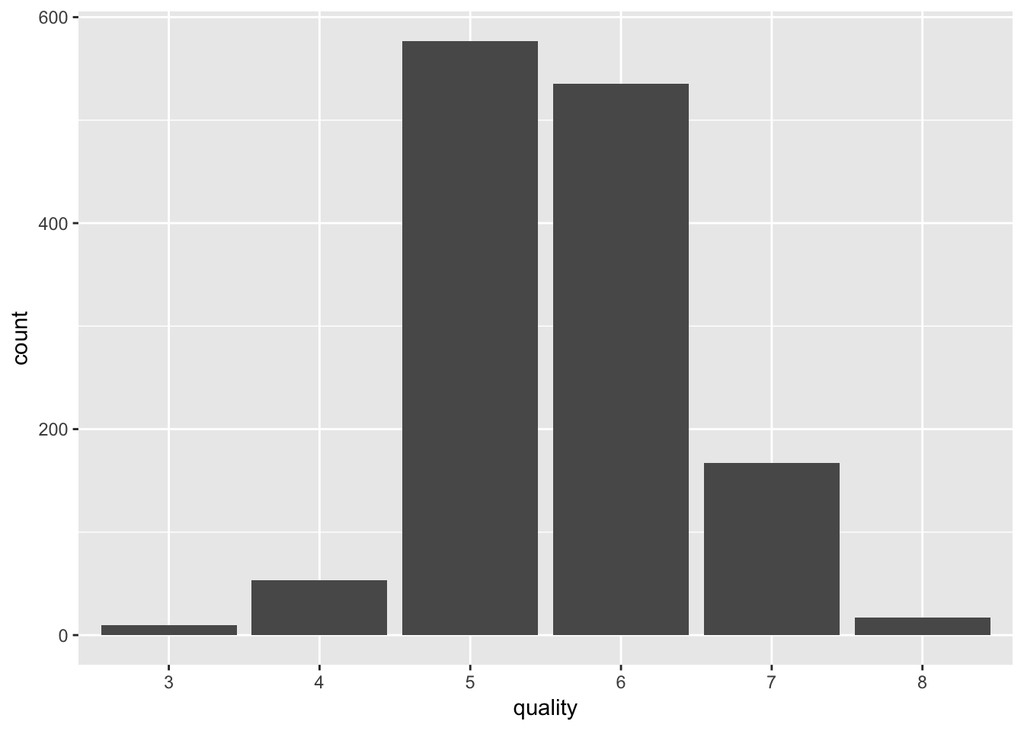

从红酒品质评级的直方图来看，大部分红酒的评级处于中等水平。虽然评级的分值设定为0-10，但就本数据集来说，红酒的评级处于3-8的范围内，并没有出现极差或极好的红酒。

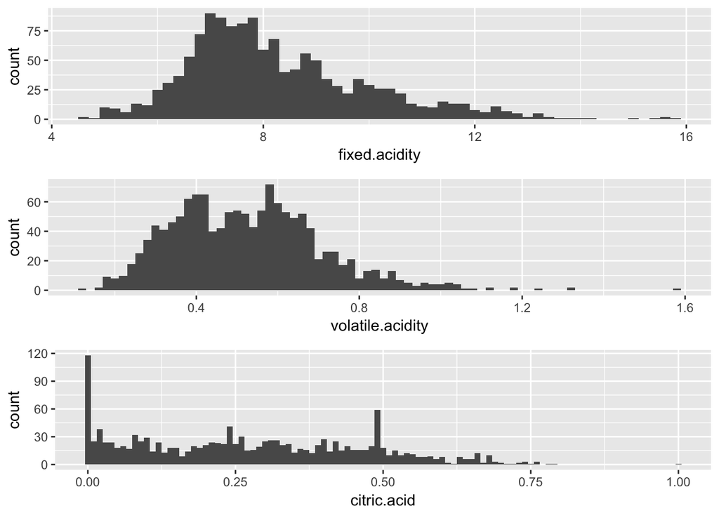

```
## [1] "Counts of wines with zero citric acid"
```

```
##
##   0
## 118
```

从红酒的三种酸性指标直方图来看，每种酸都展现了长尾分布。其中固定酸在$7\text{~}8g/dm^3$左右出现峰值，并逐步下降延伸至$16g/dm^3$。挥发性酸在$0.4\text{~}0.6g/dm^3$范围内出现了三个波峰，而挥发性酸大于$0.8g/dm^3$的红酒数量很少，原因可能与口感有关：越多的挥发性酸会增加红酒的醋味，劣化口感。

绝大部分红酒都含有小于$0.5g/dm^3$的柠檬酸，甚至有118种红酒（8.7%）完全不含有柠檬酸。根据维基百科“Acids in wine” 条目的介绍，柠檬酸只存在于极少数酿酒所用的葡萄中，这解释了红酒中的柠檬酸含量较低甚至没有的原因。

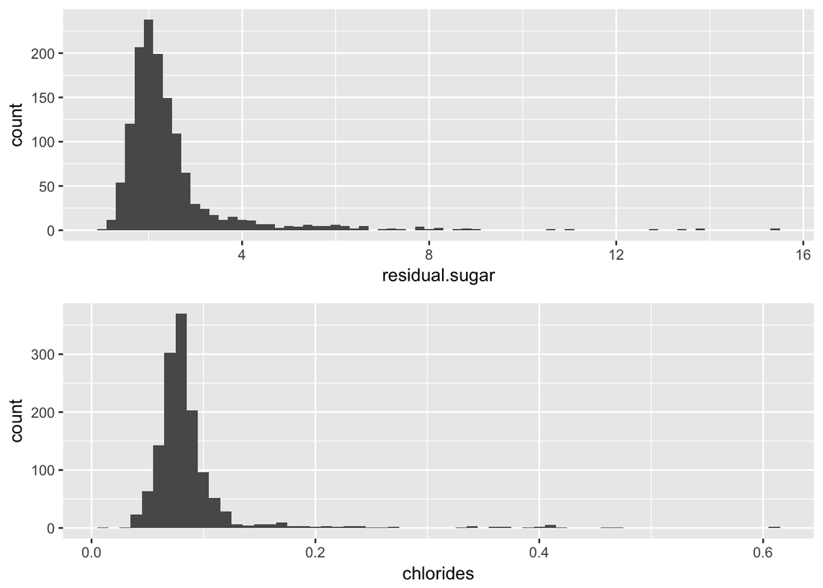

样本中大部分红酒的糖含量在$2g/dm^3$左右，而糖含量大于$4g/dm^3$的红酒较少，且没有出现超过$45g/dm^3$的甜酒。大部分红酒的盐含量在$0.08g/dm^3$左右。糖和盐的分布均呈向右长尾的钟型分布。我们再去掉长尾，放大钟型部分看一看。

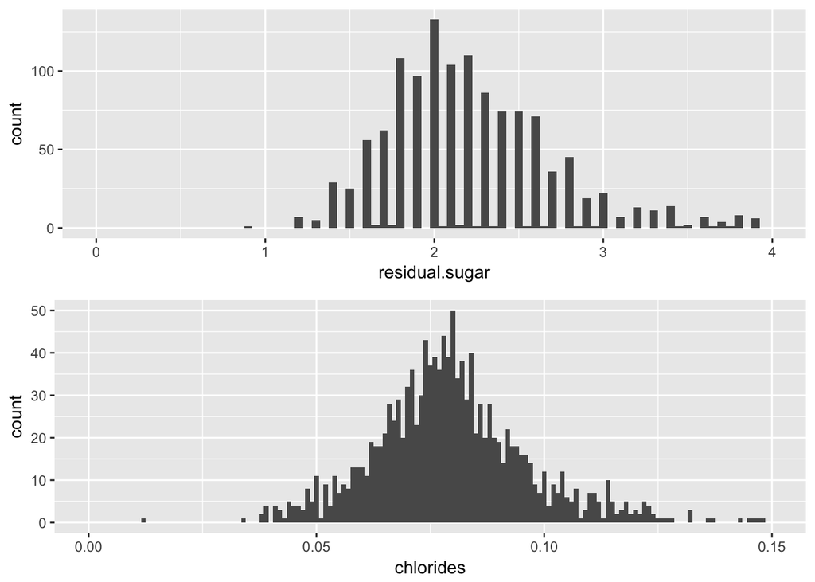

```
## [1] "Value counts of sugar attribute"
```

```
##
##  0.9  1.2  1.3  1.4  1.5  1.6 1.65  1.7 1.75  1.8  1.9    2 2.05  2.1 2.15
##    1    7    5   29   25   56    2   62    2  108   97  133    1  104    2
##  2.2 2.25  2.3 2.35  2.4  2.5 2.55  2.6 2.65  2.7  2.8 2.85  2.9 2.95    3
##  110    1   86    1   74   74    1   71    1   36   45    1   19    1   22
##  3.1  3.2  3.3  3.4 3.45  3.5  3.6 3.65  3.7 3.75  3.8  3.9    4  4.1  4.2
##    7   13   11   14    1    2    7    1    4    1    8    6    6    6    4
## 4.25  4.3  4.4  4.5  4.6 4.65  4.7  4.8    5  5.1 5.15  5.2  5.4  5.5  5.6
##    1    6    4    3    5    1    1    3    1    4    1    3    1    5    4
##  5.7  5.8  5.9    6  6.1  6.2  6.3  6.4 6.55  6.6  6.7    7  7.2  7.3  7.5
##    1    3    2    3    3    3    2    2    1    2    2    1    1    1    1
##  7.8  7.9  8.1  8.3  8.6  8.8  8.9    9 10.7   11 12.9 13.4 13.8 13.9 15.4
##    2    2    1    3    1    1    1    1    1    1    1    1    1    1    1
## 15.5
##    1
```

明显看出红酒的糖含量以$0.05g/dm^3$为最小间隔，类似离散数据的直方图，这可能与测量的精度有关。

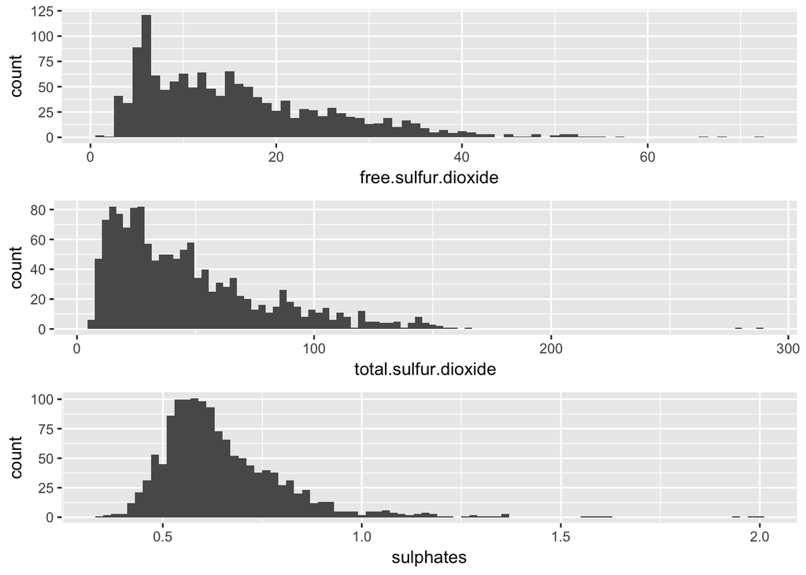

样本中大部分红酒含有的游离二氧化硫和总二氧化硫的量都在较低的水平聚集，并且两者的分布信息（直方图）有非常近似的形态，从而猜测游离二氧化硫应该在总二氧化硫中占有较为固定的比例，也即两者具有某种相关性。对于硫酸盐添加剂来说，由于其为人工添加（独立变量），故其分布呈现右长尾的钟型分布。

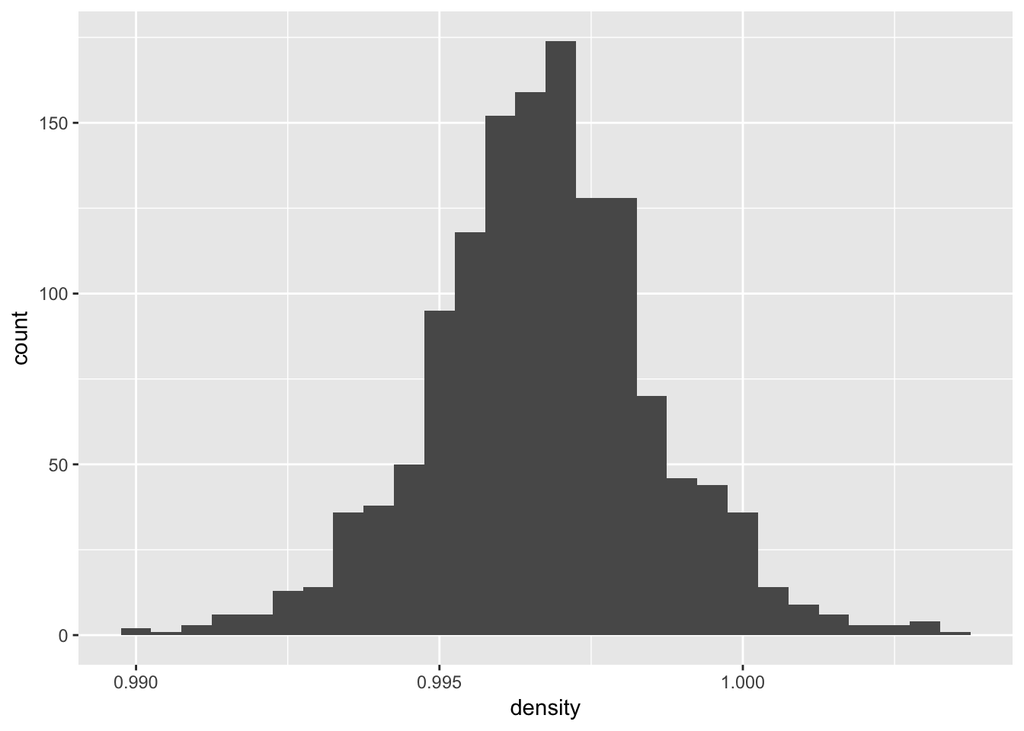

绝大部分红酒的密度都稍低于水的密度，仅有极少部分红酒的密度大于水。根据数据集的描述，酒精比例和糖含量对密度有直接影响，后续将考察这三者的相互关系。

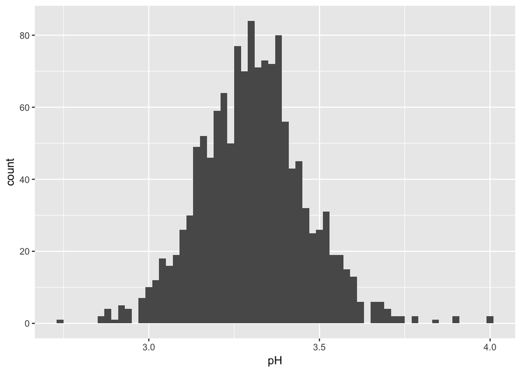

```
## [1] "Summary of pH attribute"
```

```
##    Min. 1st Qu.  Median    Mean 3rd Qu.    Max.
##    2.74    3.21    3.31    3.31    3.40    4.01
```

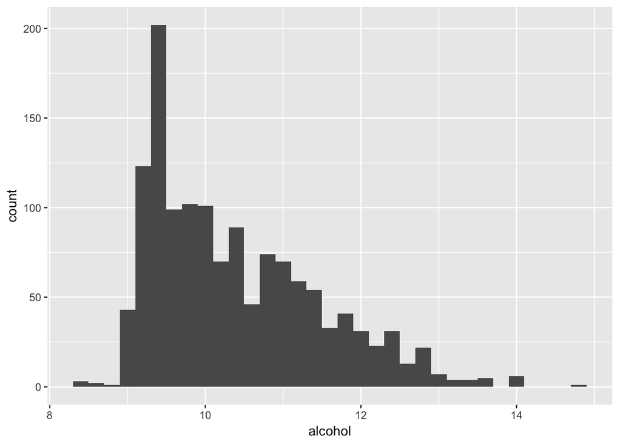

```
## [1] "Summary of alcohol attribute"
```

```
##    Min. 1st Qu.  Median    Mean 3rd Qu.    Max.
##    8.40    9.50   10.20   10.43   11.10   14.90
```

```
## [1] "Maximum of alcohol"
```

```
## [1] 14.9
```

红酒的度数（体积比例）呈右偏斜分布，约75%的红酒低于11度，最高度的红酒为14.9度。

# 单变量分析

### 你的数据集结构是什么？

数据集中有1599条红酒样本记录，及其11个连续变量（固定酸、挥发性酸、柠檬酸、糖、盐、游离二氧化硫、总二氧化硫、密度、酸碱值、硫酸盐、酒精含量）和1个离散变量–品质评级（0-非常差，到10-非常好）。

### 你的数据集内感兴趣的主要特性有哪些？

1. 红酒中游离二氧化硫和总二氧化硫是否存在某些关联度？
2. 酒精比例和糖含量对红酒密度有什么样的影响？
3. 什么因素或因素组合会影响红酒的酸碱值？
4. 什么因素或因素间的组合会影响红酒的评分等级？

### 你认为数据集内哪些其他特征可以帮助你探索兴趣特点？

根据查阅的外部资料，红酒的口感会受到单宁、酸、糖和酒精含量的影响。在当前的数据集中，已经有具体的各类酸、糖和酒精含量数据，其组合应该能对于红酒的评级信息有一定的预见能力。

### 根据数据集内已有变量，你是否创建了任何新变量？

没有，原因在于考虑到各项指标相对独立，不够成相互依存或形成某一更大整体指标的情况。

### 在已经探究的特性中，是否存在任何异常分布？你是否对数据进行一些操作，如清洁、调整或改变数据的形式？如果是，你为什么会这样做？

在探索后发现，数据集中有240条完全一样的记录，考虑到红酒这一标的物很难在11个连续变量上具有完全一致的数值，为了确保EDA的准确性（避免重复不真实数据影响分布和回归模型的结果），该部分数据在探索前已经移除。

# 双变量绘图选择

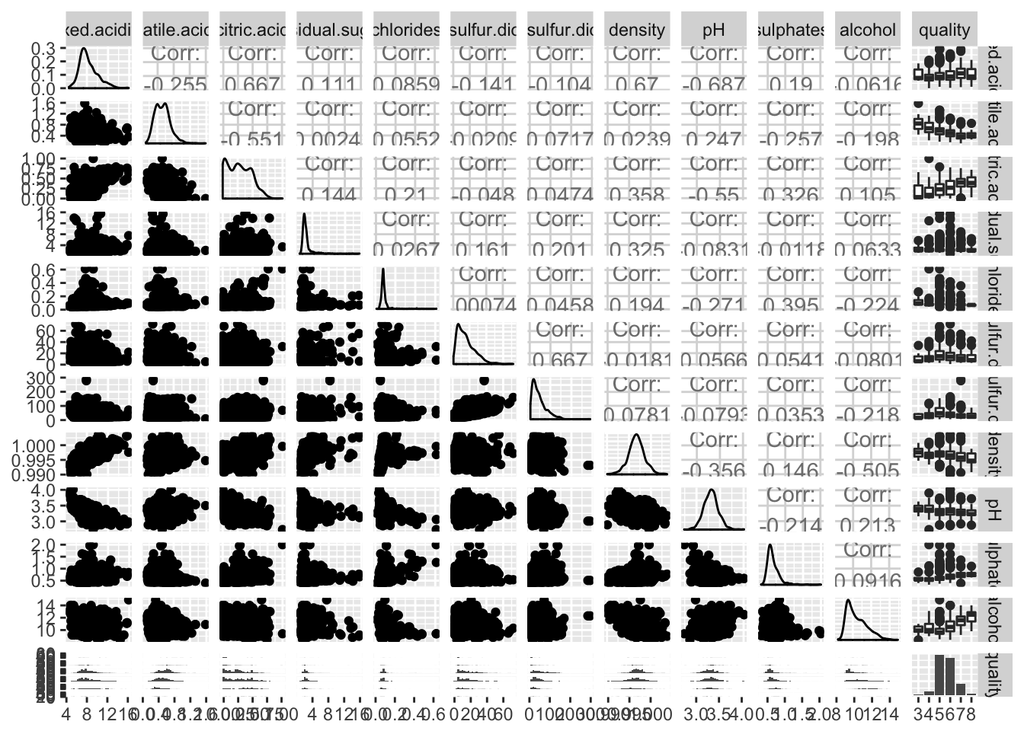

从相关度矩阵中最后一列的箱形图可以看出，挥发性酸与红酒的品质评级呈负相关关系，而柠檬酸、硫酸盐添加剂和酒精浓度与品质评级呈正相关关系。其他因素对于红酒的品质评级没有明显的趋势性影响。

对于在单变量探索中发现的问题，我们逐个讨论：

1. 红酒中游离二氧化硫和总二氧化硫是否存在某些关联度？– 相关系数0.667，显示出较明显的线性关系。

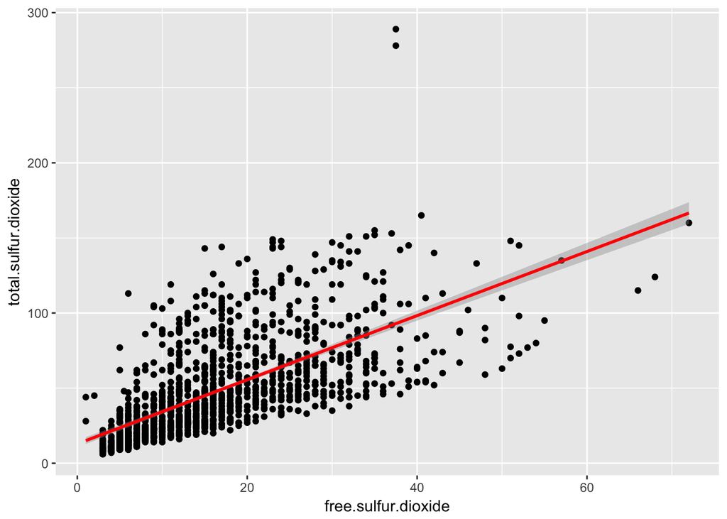

```
## [1] "Linear model of free and total sulfur dioxide, with corresponding significance test"
```

```
##
## Call:
## lm(formula = rw$total.sulfur.dioxide ~ rw$free.sulfur.dioxide)
##
## Residuals:
##     Min      1Q  Median      3Q     Max
## -56.602 -13.617  -7.448   7.615 196.070
##
## Coefficients:
##                        Estimate Std. Error t value Pr(>|t|)
## (Intercept)            12.91344    1.22965    10.5   <2e-16 ***
## rw$free.sulfur.dioxide  2.13376    0.06466    33.0   <2e-16 ***
## ---
## Signif. codes:  0 '***' 0.001 '**' 0.01 '*' 0.05 '.' 0.1 ' ' 1
##
## Residual standard error: 24.89 on 1357 degrees of freedom
## Multiple R-squared:  0.4452, Adjusted R-squared:  0.4448
## F-statistic:  1089 on 1 and 1357 DF,  p-value: < 2.2e-16
```

进一步从散点图和线性回归的结果来看，R-squared为0.44，且t-test的p值远小于0.05，故基本可以得出结论：除固定部分外（截距12.91），游离二氧化硫占总二氧化硫其余部分的约一半的比例（权重为2.13）。

2. 酒精比例和糖含量对红酒密度有什么样的影响？

根据相关度矩阵中的结果，结合单变量中的猜测，与密度最为相关的是固定酸含量（相关系数0.67），而原本猜测中的酒精浓度也与密度关联较大（相关系数-0.505）。但糖、柠檬酸、pH值（中间变量/因变量，受其他自变量的影响，如固定酸和柠檬酸）与密度相关性较低（相关系数绝对值在0.32～0.35左右）。

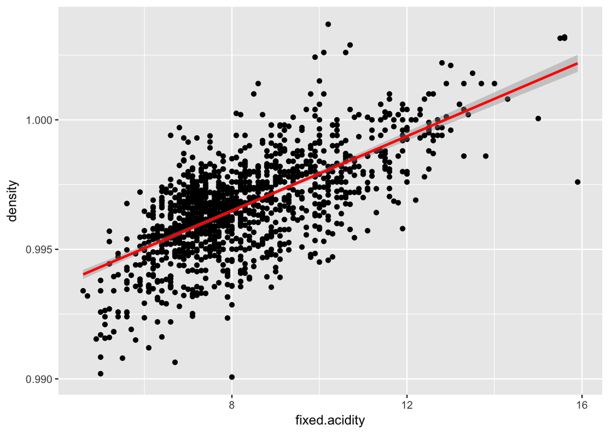

```
## [1] "Linear model of fixed.acidity and density, with corresponding significance test"
```

```
##
## Call:
## lm(formula = rw$density ~ rw$fixed.acidity)
##
## Residuals:
##        Min         1Q     Median         3Q        Max
## -0.0064150 -0.0007590  0.0001003  0.0009360  0.0056186
##
## Coefficients:
##                   Estimate Std. Error t value Pr(>|t|)
## (Intercept)      9.907e-01  1.841e-04 5383.00   <2e-16 ***
## rw$fixed.acidity 7.211e-04  2.168e-05   33.26   <2e-16 ***
## ---
## Signif. codes:  0 '***' 0.001 '**' 0.01 '*' 0.05 '.' 0.1 ' ' 1
##
## Residual standard error: 0.001388 on 1357 degrees of freedom
## Multiple R-squared:  0.4492, Adjusted R-squared:  0.4488
## F-statistic:  1107 on 1 and 1357 DF,  p-value: < 2.2e-16
```

进一步从散点图和线性回归结果验证固定酸与密度间的关系，R-squared为0.45，t-test远小于0.5，可以确定两者线性相关。

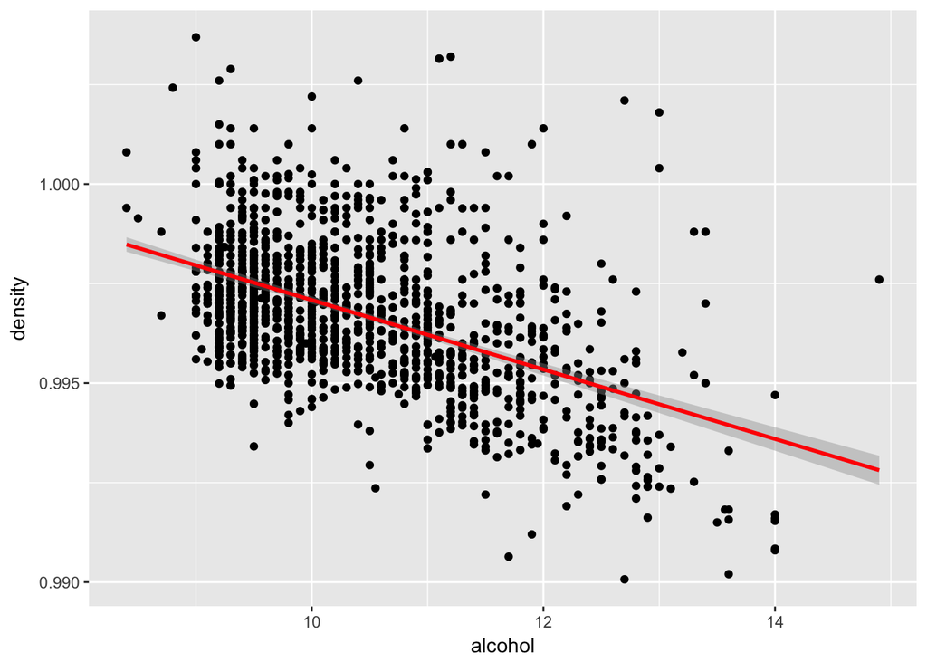

```
## [1] "Linear model of alcohol and density, with corresponding significance test"
```

```
##
## Call:
## lm(formula = rw$density ~ rw$alcohol)
##
## Residuals:
##        Min         1Q     Median         3Q        Max
## -0.0049633 -0.0010855 -0.0002321  0.0008120  0.0073690
##
## Coefficients:
##               Estimate Std. Error t value Pr(>|t|)
## (Intercept)  1.006e+00  4.244e-04 2369.70   <2e-16 ***
## rw$alcohol  -8.722e-04  4.047e-05  -21.55   <2e-16 ***
## ---
## Signif. codes:  0 '***' 0.001 '**' 0.01 '*' 0.05 '.' 0.1 ' ' 1
##
## Residual standard error: 0.001614 on 1357 degrees of freedom
## Multiple R-squared:  0.255,  Adjusted R-squared:  0.2545
## F-statistic: 464.5 on 1 and 1357 DF,  p-value: < 2.2e-16
```

从酒精浓度和密度的散点图来看，相较于固定酸含量与密度的关系，其围绕一次线性拟合线的扩散程度较高，故其相关系数较低。而当酒精浓度大于12%后，密度基本低于拟合线水平，显示出线性拟合对于此部分数据解释性较弱。这种较弱的解释性也反映在线性回归的结果中，R-squared只有0.26。

3. 什么因素或因素组合会影响红酒的酸碱值？